# Pizza Sales - A Case Study

### Preprocessing

Please refer to `./scripts/clean_data.R` for loading and tidying the raw data. After loading the relevant part of the raw excel file, the following steps were done:

1. Clean variable names
2. Clean `year` and `week` variables
3. Filter data for week 53
4. Create a clean `date` variable from `year` and `week`
5. Combine all calendar variables to a single `holiday` variable
6. Sum all own campaign variables to single `own_campaigns` variable, since they do not overlapo in time
7. Sum all competitor campaign variables to single `competitor_campaigns_sum` variable
8. Average all competitor campaign variables to single `competitor_campaigns_mean` variable
9. Sum all own and competitor campaign variables to single `campaigns_sum` variable
10. Select relevant variables and write data to `./data/processed/data_clean.feather`

Load and preview tidy data frame.

| year | week | date | pizza | price_offer | holiday | temperature | precipitation | sun | own_campaigns | campaigns_sum | competitor_campaigns_mean | competitor_campaigns_sum | competitor_1 | competitor_2 | competitor_3 | competitor_4 | competitor_5 | competitor_6 | competitor_7 |
| --- | --- | --- | --- | --- | --- | --- | --- | --- | --- | --- | --- | --- | --- | --- | --- | --- | --- | --- | --- |
| 2017 | 1 | 2017-01-02 | 100.0000 | 0.0000000 | 0 | 1.3176236 | 38.378854 | 2.313863 | 0 | 31.4 | 4.485714 | 31.4 | 0 | 0.0 | 0 | 0 | 0 | 31.4 | 0 |
| 2017 | 2 | 2017-01-09 | 221.4754 | 15.2840348 | 0 | 1.0950881 | 47.073025 | 1.563084 | 0 | 22.0 | 3.142857 | 22.0 | 0 | 0.0 | 0 | 0 | 0 | 22.0 | 0 |
| 2017 | 3 | 2017-01-16 | 131.2703 | 2.6571293 | 0 | -0.9988291 | 28.243873 | 3.924862 | 0 | 115.2 | 16.457143 | 115.2 | 0 | 102.9 | 0 | 0 | 0 | 12.3 | 0 |
| 2017 | 4 | 2017-01-23 | 127.8533 | 2.4130594 | 0 | -6.6542909 | 15.761124 | 7.094424 | 0 | 178.4 | 25.485714 | 178.4 | 0 | 159.4 | 0 | 0 | 0 | 19.0 | 0 |
| 2017 | 5 | 2017-01-30 | 146.7554 | 4.3381326 | 0 | 0.2510722 | 28.865521 | 3.882068 | 0 | 17.0 | 2.428571 | 17.0 | 0 | 0.0 | 0 | 0 | 0 | 17.0 | 0 |
| 2017 | 6 | 2017-02-06 | 114.3695 | 0.2032814 | 0 | -8.0983947 | 7.970033 | 11.050375 | 0 | 28.7 | 4.100000 | 28.7 | 0 | 0.0 | 0 | 0 | 0 | 28.7 | 0 |

A first glimpse at the central tendency our variables to get a first idea of our data set.

|  | vars | n | mean | sd | min | max | range | se |
| --- | --- | --- | --- | --- | --- | --- | --- | --- |
| year | 1 | 260 | 2019.00 | 1.42 | 2017.00 | 2021.00 | 4.00 | 0.09 |
| week | 2 | 260 | 26.50 | 15.04 | 1.00 | 52.00 | 51.00 | 0.93 |
| pizza | 3 | 260 | 135.74 | 35.46 | 66.87 | 274.78 | 207.91 | 2.20 |
| price_offer | 4 | 260 | 3.85 | 6.12 | 0.00 | 33.99 | 33.99 | 0.38 |
| own_campaigns | 5 | 260 | 35.98 | 63.93 | 0.00 | 245.30 | 245.30 | 3.96 |
| campaigns_sum | 6 | 260 | 238.92 | 179.64 | 4.50 | 877.10 | 872.60 | 11.14 |
| competitor_campaigns_mean | 7 | 260 | 28.99 | 23.56 | 0.64 | 119.27 | 118.63 | 1.46 |
| competitor_campaigns_sum | 8 | 260 | 202.94 | 164.91 | 4.50 | 834.90 | 830.40 | 10.23 |

We can see that we have **data from five years 2017-2021.** Our **own campaigns reach on average more people than our competitors’ campaigns** even though our reach varies way more. However, all competitors combined have of course a way greater reach than our campaigns.

### Task 1: Plot variables

Let’s first have a look at our main **KPI pizza sales** from 2017 through 2021:

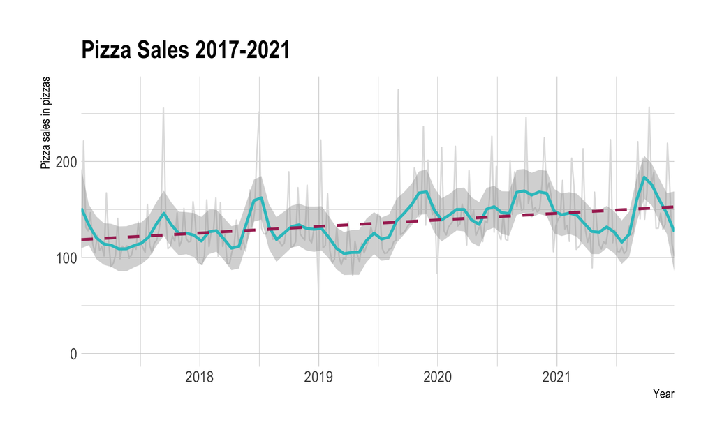

First, let’s look at the same data aggregated by year.

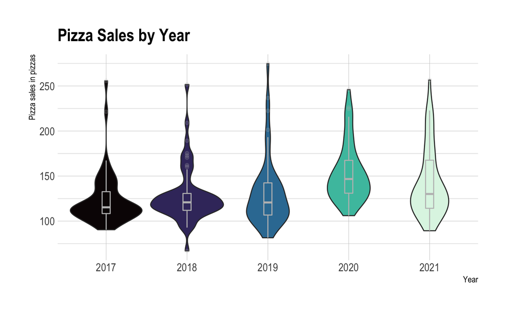

We see that the trend line in the first plot missed that 2021 actually saw a slight decrease in sales, which we can also see in below table that gives us **total sales per year.**

| year | total_pizza |
| --- | --- |
| 2017 | 6431.56 |
| 2018 | 6673.50 |
| 2019 | 6807.43 |
| 2020 | 7957.85 |
| 2021 | 7422.39 |

Let’s look at the same data but with some other variables that could drive our sales, beginning with **sales offer**, which gives us the deviation from the standard price of our frozen pizza in percent.

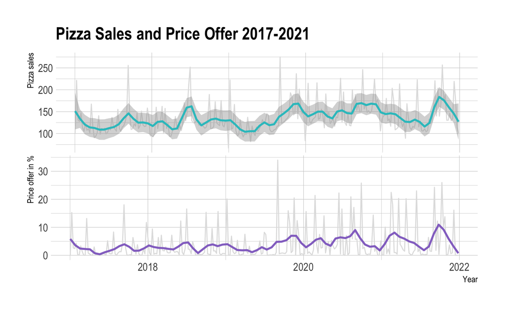

Here we can already see a clear correlation between pizza price and sales. Let’s look at the sales data in combination with our own **campaign data.**

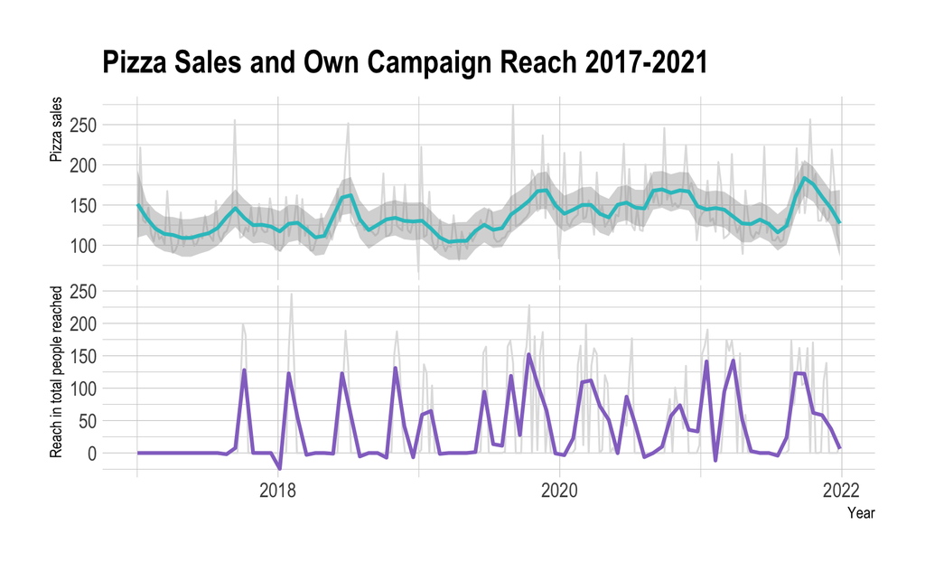

We can see that some but not all campaigns drive our sales. Let’s have a look at our **competitors’ campaigns**. Specifically, we will look at the **total reach of all competitors combined.**

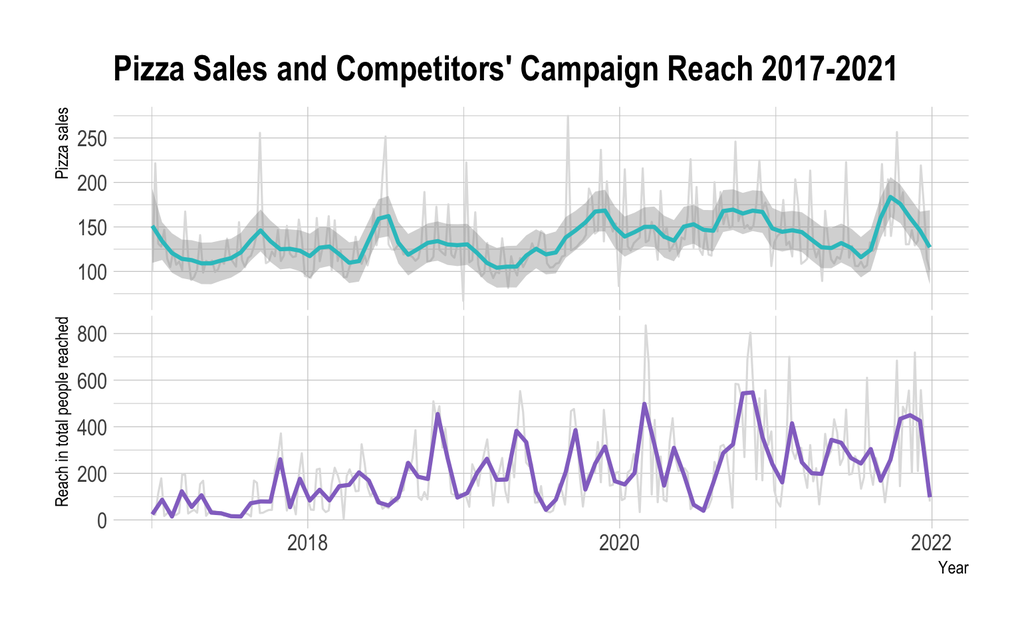

Let’s look at a **correlation matrix of pizza sales, price offer, own campaign and competitor campaign reach.**

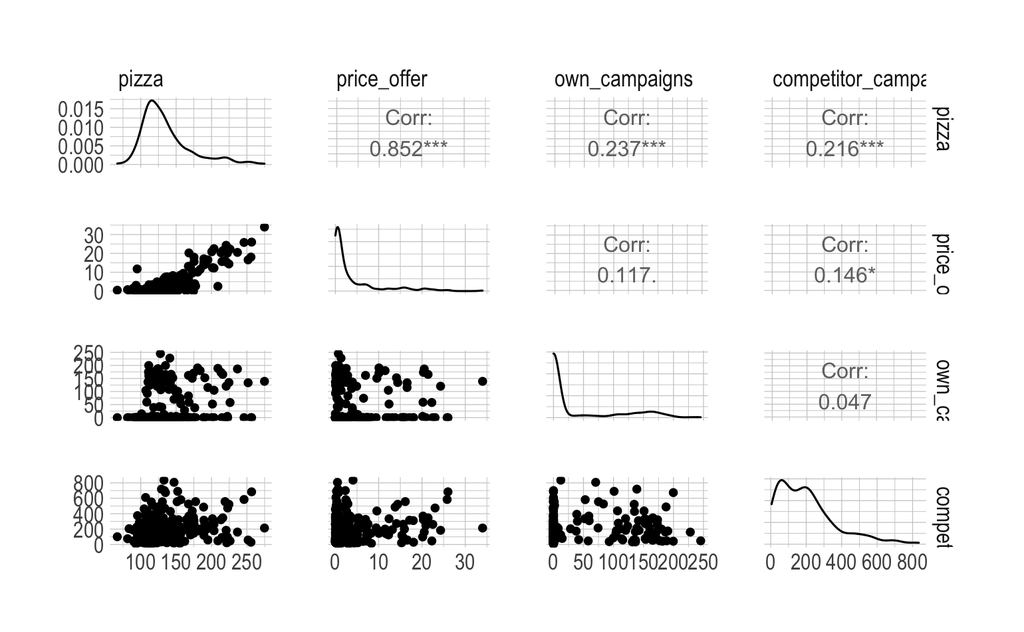

These all seem to be great candidates for sales predictors.

Finally, let’s also have a look at the weather variables, i.e., **temperature and precipitation** over the five years, aggregated by month.

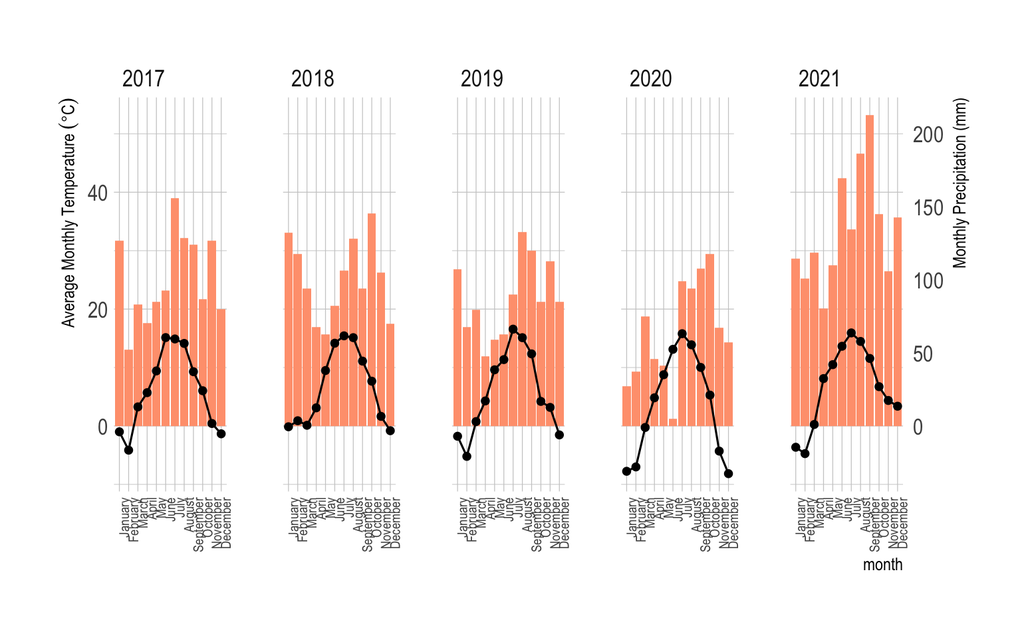

**2021 was very rainy,** which might explain the lower pizza sales to some degree. However, it was also the year (almost) post pandemic. Let’s see if a correlation plot could corroborate this assumption.

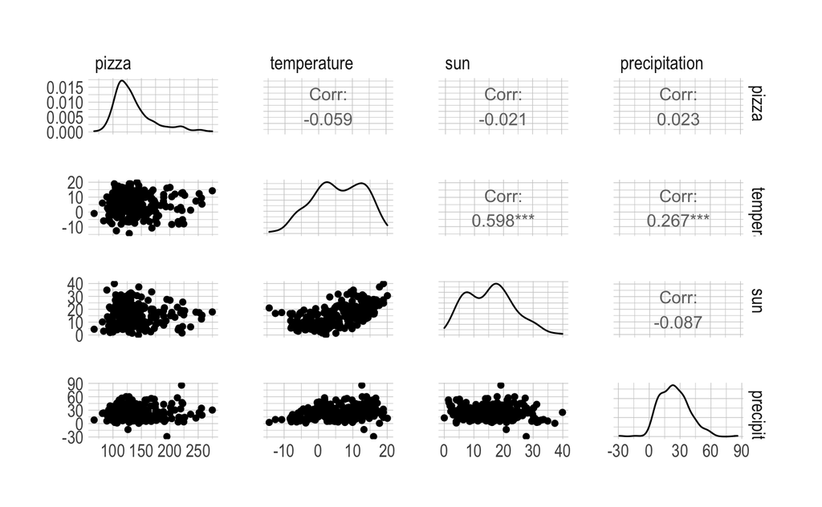

Not really. However, **temperature correlates both with hours of sun per day and precipitation in millimeters**, so we might use only temperature as a predictor later on.

For now, we can summarize that **sales offer, our own as well as our competitors’ campaign reach might be valuable sales predictors**.

### Task 2: Summary table

A table with **min, max, total per variable**.

| variable | min | max | total |
| --- | --- | --- | --- |
| competitor_campaigns_sum | 4.50000 | 834.90000 | 52765.401 |
| holiday | 0.00000 | 3.00000 | 51.000 |
| own_campaigns | 0.00000 | 245.30000 | 9353.800 |
| pizza | 66.87409 | 274.77972 | 35292.730 |
| precipitation | -29.01296 | 85.89522 | 6348.618 |
| price_offer | 0.00000 | 33.99354 | 1001.962 |
| sun | 0.00000 | 39.88604 | 4025.189 |
| temperature | -14.34048 | 20.05144 | 1510.818 |

### Task 3: Model pizza sales

For this task, we split data into a **training and test set.** Let’s assume we have data only for 2017-2020 and use it to predict the 2021 data.

```
Call:
lm(formula = .outcome ~ ., data = dat, na.action = ..1)

Residuals:
    Min      1Q  Median      3Q     Max
-64.572  -9.599  -1.425   7.130  69.279

Coefficients: (1 not defined because of singularities)
              Estimate Std. Error t value Pr(>|t|)
(Intercept)   118.0239     3.0292  38.963  < 2e-16 ***
price_offer    27.8689     1.1420  24.403  < 2e-16 ***
own_campaigns   3.7479     1.1756   3.188  0.00167 **
competitor_1        NA         NA      NA       NA
competitor_2   -2.2893     1.1477  -1.995  0.04745 *
competitor_3    0.2433     1.2083   0.201  0.84062
competitor_4    1.8004     1.6947   1.062  0.28938
competitor_5    0.1514     1.2667   0.119  0.90500
competitor_6    0.2505     1.1620   0.216  0.82957
competitor_7    3.6210     1.6797   2.156  0.03231 *
temperature    -1.6556     1.1625  -1.424  0.15598
holiday        -6.8958     1.1422  -6.037 7.66e-09 ***
---
Signif. codes:  0 ‘***’ 0.001 ‘**’ 0.01 ‘*’ 0.05 ‘.’ 0.1 ‘ ’ 1

Residual standard error: 16.15 on 197 degrees of freedom
Multiple R-squared:  0.7926,    Adjusted R-squared:  0.782
F-statistic: 75.28 on 10 and 197 DF,  p-value: < 2.2e-16
```

Competitor 1 seems to be correlated with our own campaigns or offers. Other than that, we see that the residuals are close to normally distributed, confirming a basic model assumption.

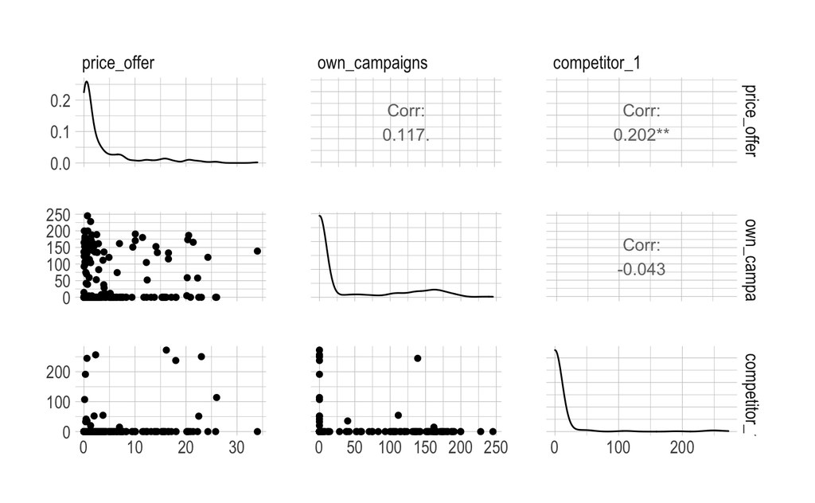

Competitor 1 seems to run campaigns when our brand has a good price offer, therefore conflating our model. We’ll exclude this competitor.

```
Call:
lm(formula = .outcome ~ ., data = dat, na.action = ..1)

Residuals:
    Min      1Q  Median      3Q     Max
-64.572  -9.599  -1.425   7.130  69.279

Coefficients:
              Estimate Std. Error t value Pr(>|t|)
(Intercept)   118.0239     3.0292  38.963  < 2e-16 ***
price_offer    27.8689     1.1420  24.403  < 2e-16 ***
own_campaigns   3.7479     1.1756   3.188  0.00167 **
competitor_2   -2.2893     1.1477  -1.995  0.04745 *
competitor_3    0.2433     1.2083   0.201  0.84062
competitor_4    1.8004     1.6947   1.062  0.28938
competitor_5    0.1514     1.2667   0.119  0.90500
competitor_6    0.2505     1.1620   0.216  0.82957
competitor_7    3.6210     1.6797   2.156  0.03231 *
temperature    -1.6556     1.1625  -1.424  0.15598
holiday        -6.8958     1.1422  -6.037 7.66e-09 ***
---
Signif. codes:  0 ‘***’ 0.001 ‘**’ 0.01 ‘*’ 0.05 ‘.’ 0.1 ‘ ’ 1

Residual standard error: 16.15 on 197 degrees of freedom
Multiple R-squared:  0.7926,    Adjusted R-squared:  0.782
F-statistic: 75.28 on 10 and 197 DF,  p-value: < 2.2e-16
```

Let’s assemble our **final model** and see how well it does on the **unseen 2021 data.**

```
Call:
lm(formula = .outcome ~ ., data = dat, na.action = ..1)

Residuals:
    Min      1Q  Median      3Q     Max
-64.988 -10.696  -0.883   7.177  67.256

Coefficients:
              Estimate Std. Error t value Pr(>|t|)
(Intercept)    117.454      1.653  71.036  < 2e-16 ***
price_offer     27.796      1.132  24.561  < 2e-16 ***
own_campaigns    3.862      1.137   3.395 0.000825 ***
competitor_2    -1.912      1.125  -1.700 0.090624 .
competitor_7     5.073      1.132   4.483 1.23e-05 ***
holiday         -6.751      1.132  -5.962 1.10e-08 ***
---
Signif. codes:  0 ‘***’ 0.001 ‘**’ 0.01 ‘*’ 0.05 ‘.’ 0.1 ‘ ’ 1

Residual standard error: 16.1 on 202 degrees of freedom
Multiple R-squared:  0.7885,    Adjusted R-squared:  0.7833
F-statistic: 150.7 on 5 and 202 DF,  p-value: < 2.2e-16
```

Again, first-glimpse model diagnostics look promising: Normally distributed residuals and a solid adjusted R-squared indicating that our model is able to explain 78.33% of the variance in the data.

Let’s test this on the unseen test set (the 2021 data). Below we see basic model performance metrics **RMS, Rsquared, and MAE.**

```
      RMSE   Rsquared        MAE
22.1048997  0.7706168 17.8241649
```

We can see that we have a reasonably low prediction error, and the R-squared we get is highly comparable to the one we got for our training set, which is likely due to the cross validation approach we used. Let’s plot the **predicted versus actual pizza sales for 2021.**

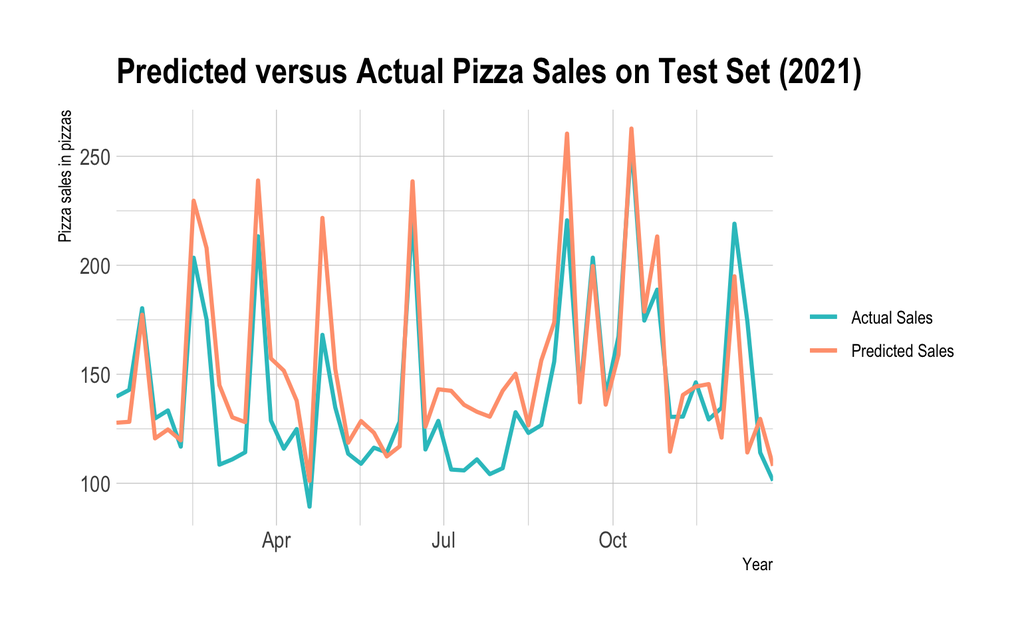

```r
test %>%
  ggplot(aes(x = date, y = pizza,
             color = "Actual Sales")) +
  ## Add pizza sales
  geom_line(aes(x = date, y = pizza),
    size=1
  )+
  ## Add predictions
  geom_line(aes(y=predictions,
                color = "Predicted Sales"),
            size=1) +
  ## Style
  ggtitle("Predicted versus Actual Pizza Sales on Test Set (2021)") +
  ylab("Pizza sales in pizzas") +
  theme_ipsum(
    plot_title_size = 14,
    grid = "Y"
  ) +
  scale_x_date(expand = c(0,0))+
  xlab("Year") +
  theme_ipsum(grid = TRUE) +
  scale_color_manual(name = "",
                     values = c("Actual Sales" = "#2EC2C7", "Predicted Sales" = "#FFA17D")) +
  scale_linetype_manual(name = "",
                        values = c("Actual Sales" = 1, "Predicted Sales" = 2))
```

We can see that our model does a very good job, though overall slightly overestimating sales.

### Task 4: Selecting predictor variables

The **final model** was `sales ~ price_offer + own_campaigns + competitor_2 + competitor_7 + holiday`. This was based on the following:

1. All own campaigns were combined to one variable since there was no overlap in time between campaigns
2. `competitor_1` seemed to run campaigns when our brand has good price offers, which leads to correlation of these variables, and was thus removed.
3. The rest of the `competitor_n` campaigns were removed based on the low influence on our sales variable as indicated by their coefficients.
4. _Weather variables__ `sun` and `precipitation` were removed since they correlated both with temperature.
5. `temperature` was removed based on its coefficient.
6. `holiday` had a strong negative impact, possibly indicating that some stores selling our product are closed on these days and therefore stayed in the model.